# 평가문제

김용태

July 27, 2018

# 1. 주택허가 건수는 경제상황을 알 수 있게 해주는 중요한 요인 중 하나로 경기가 침체국면으로 가기 전에 감소하고 침체가 끝나기 전에 증가한다. 따라서 이후에 경기 상황을 예측하고자 1997년~2017년까지의 분기별 자료 “house.csv”를 얻었다. 이 자료를 이용하여 지수평활법과 ARIMA 모형을 고려하여 최적의 모형을 선택하고 3시점 앞까지 예측하는 과정을 R 프로그램으로 작성하시오.

> 데이터 불러오기 및 시계열 그래프

```r
library(forecast)
library(tseries)

setwd("e:/mydata/")

h.data<-read.csv("house.csv", skip=1)

ts.data<-ts(h.data$house, start=c(1997, 1), frequency=4)
ts.data
```

```
##       Qtr1  Qtr2  Qtr3  Qtr4
## 1997  83.3  83.2 105.3 117.7
## 1998 104.6 108.8  93.9  86.1
## 1999  83.0 102.4 119.6 141.4
## 2000 158.6 161.3 158.2 136.1
## 2001 121.9  97.7 103.3  92.7
## 2002 106.8 102.1 110.3 114.1
## 2003 109.1 105.4  97.6 100.7
## 2004 102.7 110.9 120.2 131.3
## 2005 138.9 130.9 123.1 110.8
## 2006 108.8 103.8  97.0  93.2
## 2007  89.7  89.9  90.2  89.6
## 2008  85.8  96.9 112.7 122.7
## 2009 119.8 117.4 111.9 104.7
## 2010  98.3  94.9  93.3  90.9
## 2011  91.9  97.2 104.7 107.7
## 2012 108.2 110.7 113.2 114.6
## 2013 112.2 120.2 122.1 126.6
## 2014 122.3 115.9 116.9 110.1
## 2015 110.4 108.9 112.1 117.6
## 2016 112.2  96.0  78.0  66.9
## 2017  83.5  95.8 107.7 113.7
```

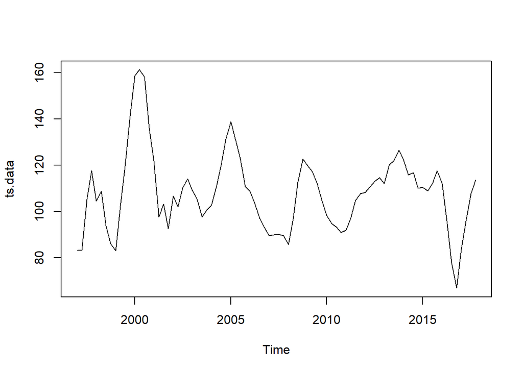

```r
plot(ts.data)
```

일정 증가하는 추세나 계절성을 특별히 보이지 않음

> 추세성, 자기상관성, 단위근 검정

```r
cor.test(1:length(ts.data), ts.data, method="spearman")
```

```
##
##  Spearman's rank correlation rho
##
## data:  1:length(ts.data) and ts.data
## S = 99036, p-value = 0.9806
## alternative hypothesis: true rho is not equal to 0
## sample estimates:
##          rho
## -0.002693194
```

p-값=0.9806>0.05=유의수준 으로 추세성 없음

```r
Box.test(ts.data, type="Ljung-Box")
```

```
##
##  Box-Ljung test
##
## data:  ts.data
## X-squared = 60.691, df = 1, p-value = 6.661e-15
```

p-값=6.661e-15<0.05=유의수준 으로 자기상관 있음

```r
PP.test(ts.data)
```

```
##
##  Phillips-Perron Unit Root Test
##
## data:  ts.data
## Dickey-Fuller = -3.6401, Truncation lag parameter = 3, p-value =
## 0.03491
```

p-값=0.03491<0.05=유의수준 으로 단위근이 존재하지 않음(정상성 만족)

> ACF와 PACF

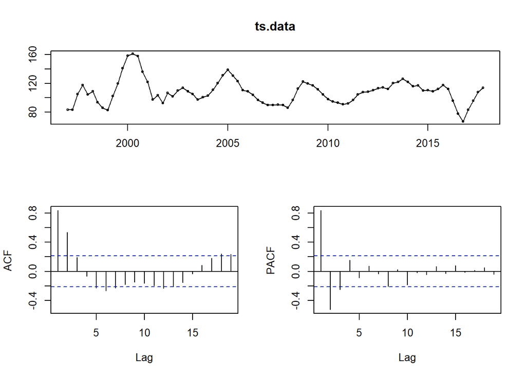

```r
tsdisplay(ts.data)
```

ACF와 PACF가 급격히 감소하는 형태가 아니고 신뢰한계를 벗어난 것이 발견

단순지수평활법과 AR(2) 또는 MA(2) 또는 ARMA(2,2) 모형등을 고려

```r
hb<-HoltWinters(ts.data, beta=F, gamma=F)
fit.ar2<-arima(ts.data, order=c(2,0,0))
fit.ma2<-arima(ts.data, order=c(0,0,2))
fit.ar2ma2<-arima(ts.data, order=c(2,0,2))
hb
```

```
## Holt-Winters exponential smoothing without trend and without seasonal component.
##
## Call:
## HoltWinters(x = ts.data, beta = F, gamma = F)
##
## Smoothing parameters:
##  alpha: 0.9999339
##  beta : FALSE
##  gamma: FALSE
##
## Coefficients:
##       [,1]
## a 113.6996
```

```r
fit.ar2
```

```
##
## Call:
## arima(x = ts.data, order = c(2, 0, 0))
##
## Coefficients:
##          ar1      ar2  intercept
##       1.3149  -0.5552   108.1018
## s.e.  0.0894   0.0900     3.4024
##
## sigma^2 estimated as 57.18:  log likelihood = -290.13,  aic = 588.26
```

```r
fit.ma2
```

```
##
## Call:
## arima(x = ts.data, order = c(0, 0, 2))
##
## Coefficients:
##          ma1     ma2  intercept
##       1.1351  0.8297   108.3303
## s.e.  0.0746  0.0584     2.5580
##
## sigma^2 estimated as 63.91:  log likelihood = -295.21,  aic = 598.43
```

```r
fit.ar2ma2
```

```
##
## Call:
## arima(x = ts.data, order = c(2, 0, 2))
##
## Coefficients:
##          ar1      ar2      ma1     ma2  intercept
##       1.3021  -0.6073  -0.0936  0.3950   107.8901
## s.e.  0.2055   0.1759   0.2407  0.1411     3.2175
##
## sigma^2 estimated as 48.61:  log likelihood = -283.58,  aic = 579.15
```

> 모형의 적합성 평가

```r
fit.hb<-forecast(hb)
round(accuracy(fit.hb),3); round(accuracy(fit.ar2),3); round(accuracy(fit.ma2),3); round(accuracy(fit.ar2ma2),3)
```

```
##                 ME  RMSE MAE    MPE  MAPE  MASE  ACF1
## Training set 0.366 9.489 7.4 -0.033 6.934 0.382 0.437
```

```
##                 ME  RMSE   MAE    MPE  MAPE  MASE   ACF1
## Training set 0.093 7.562 5.969 -0.415 5.713 0.807 -0.186
```

```
##                 ME  RMSE   MAE    MPE MAPE  MASE  ACF1
## Training set 0.024 7.994 6.256 -0.834 5.93 0.845 0.246
```

```
##                 ME  RMSE   MAE    MPE  MAPE  MASE   ACF1
## Training set 0.099 6.972 5.559 -0.321 5.304 0.751 -0.021
```

정확성 통계량으로 판단하면 ARMA(2,2) 모형이 가장 좋음 모형

> 잔차의 평가
1. 잔차의 자기상관검정

```r
Box.test(fit.hb$residuals, type="Ljung-Box")
```

```
##
##  Box-Ljung test
##
## data:  fit.hb$residuals
## X-squared = 16.43, df = 1, p-value = 5.049e-05
```

```r
Box.test(fit.ar2$residuals, type="Ljung-Box")
```

```
##
##  Box-Ljung test
##
## data:  fit.ar2$residuals
## X-squared = 3.0231, df = 1, p-value = 0.08209
```

```r
Box.test(fit.ma2$residuals, type="Ljung-Box")
```

```
##
##  Box-Ljung test
##
## data:  fit.ma2$residuals
## X-squared = 5.2815, df = 1, p-value = 0.02155
```

```r
Box.test(fit.ar2ma2$residuals, type="Ljung-Box")
```

```
##
##  Box-Ljung test
##
## data:  fit.ar2ma2$residuals
## X-squared = 0.037695, df = 1, p-value = 0.8461
```

2. 잔차의 ACF와 PACF

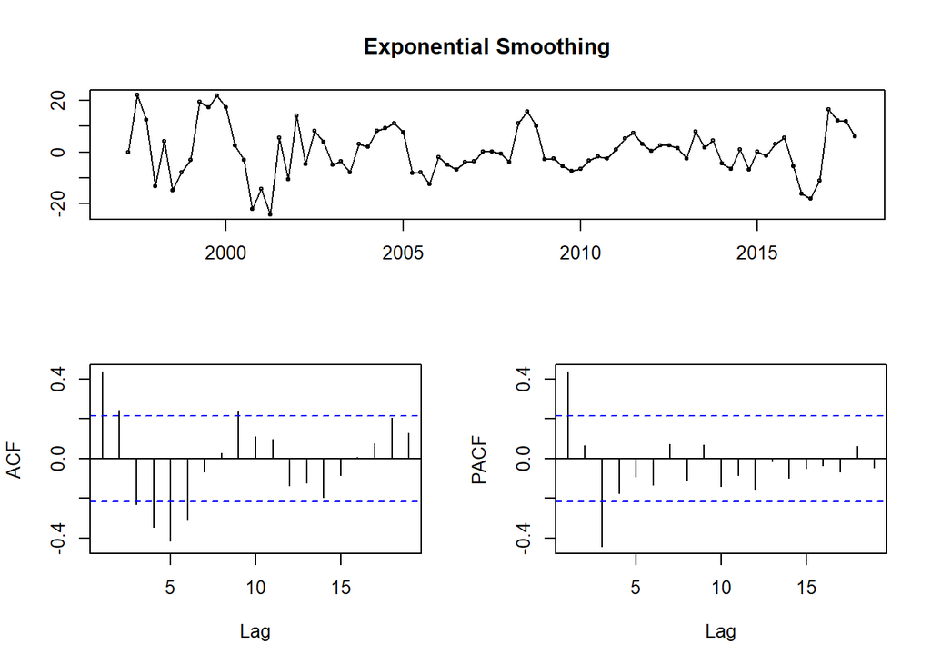

```r
tsdisplay(fit.hb$residuals, main="Exponential Smoothing")
```

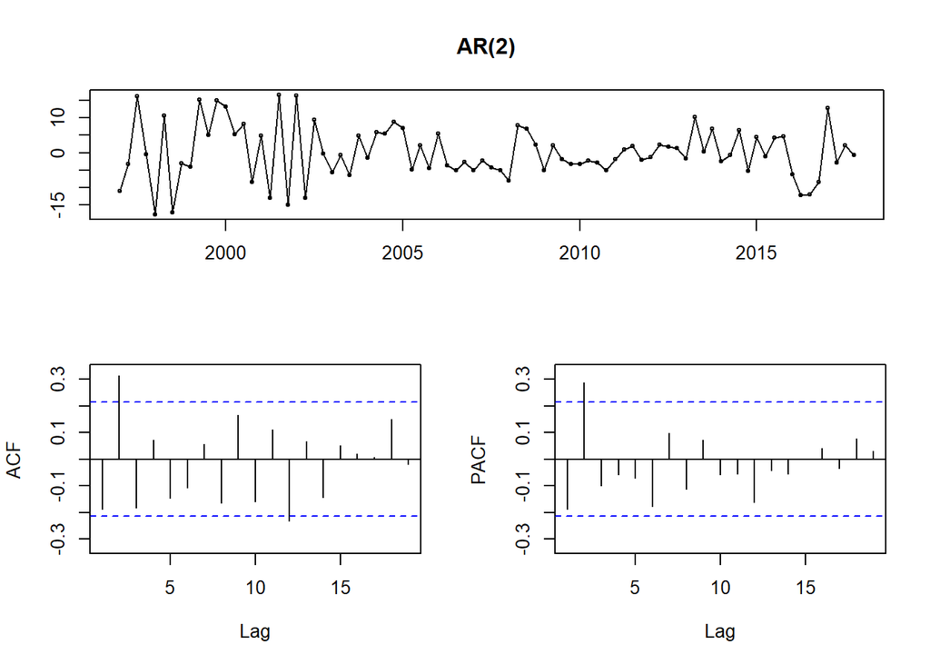

```r
tsdisplay(fit.ar2$residuals, main="AR(2)")
```

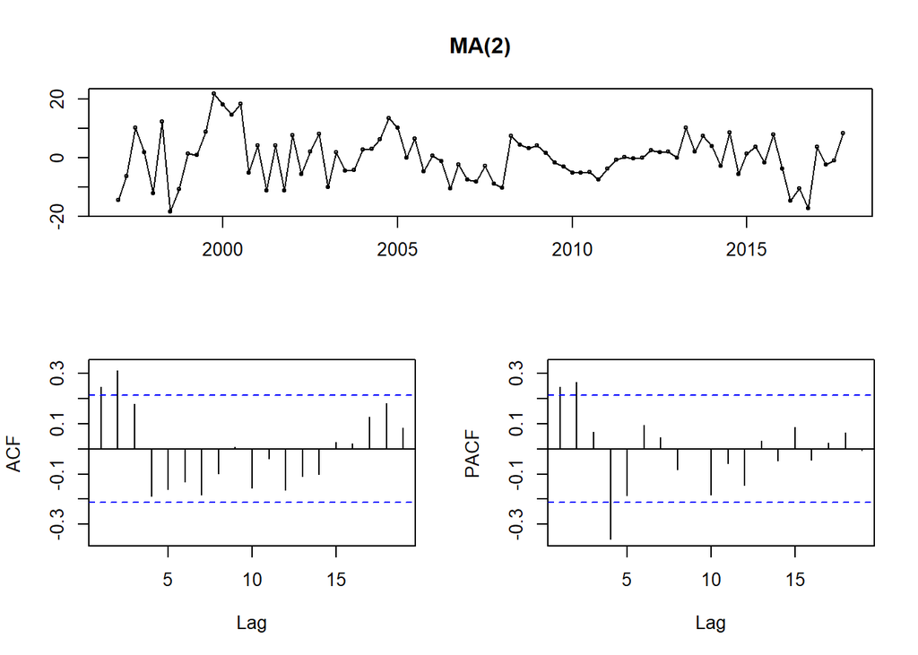

```r
tsdisplay(fit.ma2$residuals, main="MA(2)")
```

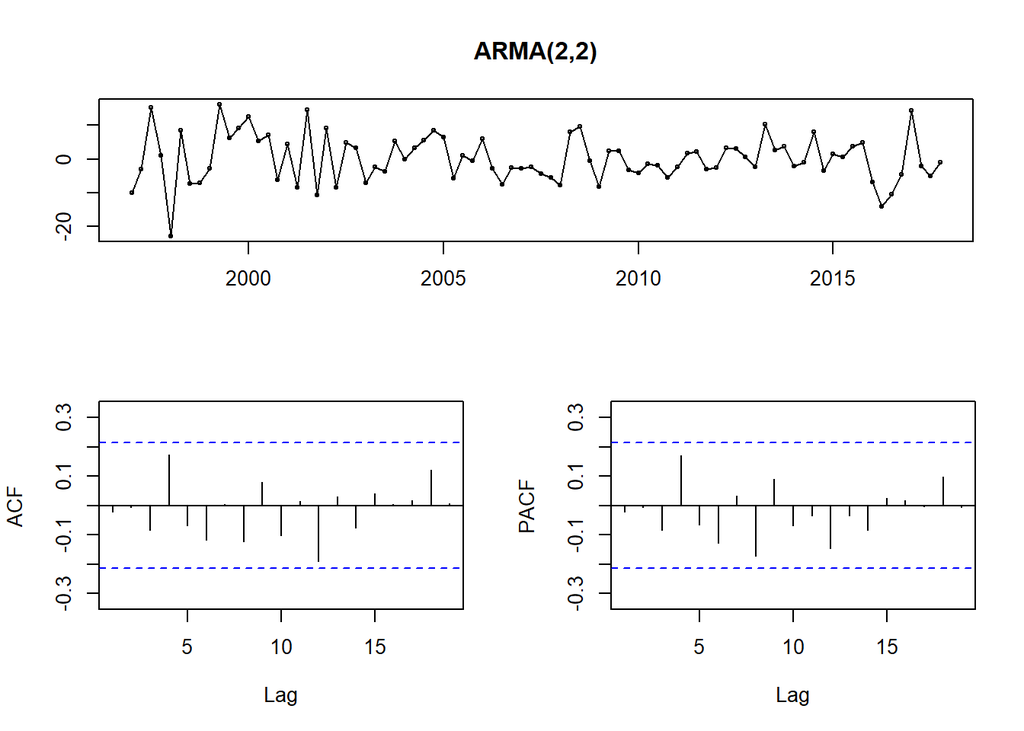

```r
tsdisplay(fit.ar2ma2$residuals, main="ARMA(2,2)")
```

ARMA(2,2)는 ACF와 PACF 값이 신뢰한계를 벗어난 것이 없음

3. 정규성검정

```r
jarque.bera.test(fit.hb$residuals[-1])
```

```
##
##  Jarque Bera Test
##
## data:  fit.hb$residuals[-1]
## X-squared = 0.029836, df = 2, p-value = 0.9852
```

```r
jarque.bera.test(fit.ar2$residuals)
```

```
##
##  Jarque Bera Test
##
## data:  fit.ar2$residuals
## X-squared = 0.16806, df = 2, p-value = 0.9194
```

```r
jarque.bera.test(fit.ma2$residuals)
```

```
##
##  Jarque Bera Test
##
## data:  fit.ma2$residuals
## X-squared = 0.33537, df = 2, p-value = 0.8456
```

```r
jarque.bera.test(fit.ar2ma2$residuals)
```

```
##
##  Jarque Bera Test
##
## data:  fit.ar2ma2$residuals
## X-squared = 0.97763, df = 2, p-value = 0.6134
```

유의수준 0.05하에서 모든 모형이 정규성 만족

4. 잔차도표

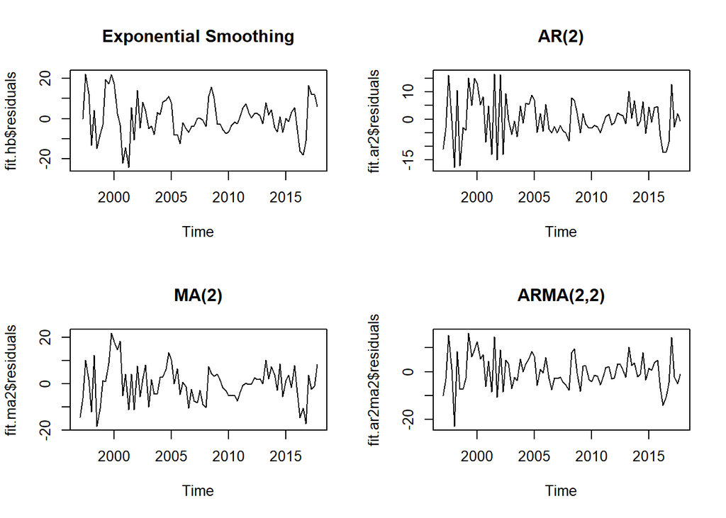

```r
layout(matrix(1:4,ncol=2,byrow=T))
plot(fit.hb$residuals, main="Exponential Smoothing")
plot(fit.ar2$residuals, main="AR(2)")
plot(fit.ma2$residuals, main="MA(2)")
plot(fit.ar2ma2$residuals, main="ARMA(2,2)")
```

잔차도표를 작성후 정상성 및 등분산성 등 만족

> 3시점 앞까지 예측

```r
forecast(hb, h=3)
```

```
##         Point Forecast     Lo 80    Hi 80    Lo 95    Hi 95
## 2018 Q1       113.6996 101.47471 125.9245 95.00324 132.3960
## 2018 Q2       113.6996  96.41157 130.9876 87.25983 140.1394
## 2018 Q3       113.6996  92.52640 134.8728 81.31799 146.0812
```

```r
forecast(fit.ar2, h=3)
```

```
##         Point Forecast     Lo 80    Hi 80     Lo 95    Hi 95
## 2018 Q1       115.6859 105.99501 125.3769 100.86494 130.5069
## 2018 Q2       114.9663  98.95724 130.9753  90.48258 139.4499
## 2018 Q3       112.9174  93.27858 132.5563  82.88241 142.9524
```

```r
forecast(fit.ma2, h=3)
```

```
##         Point Forecast     Lo 80    Hi 80     Lo 95    Hi 95
## 2018 Q1       117.0376 106.79258 127.2827 101.36918 132.7061
## 2018 Q2       115.3348  99.83615 130.8335  91.63165 139.0380
## 2018 Q3       108.3303  90.65354 126.0071  81.29603 135.3646
```

```r
forecast(fit.ar2ma2, h=3)
```

```
##         Point Forecast     Lo 80    Hi 80    Lo 95    Hi 95
## 2018 Q1       113.6142 104.67893 122.5495 99.94888 127.2795
## 2018 Q2       111.4325  97.41619 125.4487 89.99642 132.8685
## 2018 Q3       109.0263  90.46732 127.5853 80.64279 137.4098
```

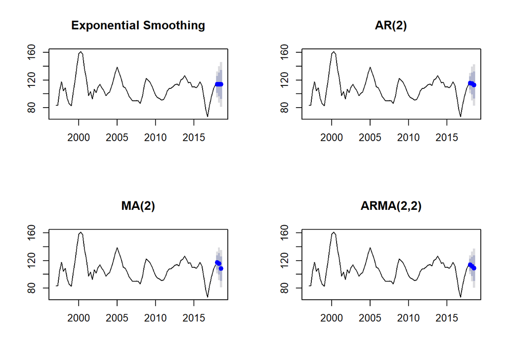

```r
layout(matrix(1:4,ncol=2,byrow=T))
plot(forecast(hb, h=3), main="Exponential Smoothing")
plot(forecast(fit.ar2, h=3), main="AR(2)")
plot(forecast(fit.ma2, h=3), main="MA(2)")
plot(forecast(fit.ar2ma2, h=3), main="ARMA(2,2)")
```

> 모형의 결정

```r
dm.test(fit.ar2$residuals, fit.ar2ma2$residuals, alternative="greater")
```

```
##
##  Diebold-Mariano Test
##
## data:  fit.ar2$residualsfit.ar2ma2$residuals
## DM = 1.5508, Forecast horizon = 1, Loss function power = 2,
## p-value = 0.06238
## alternative hypothesis: greater
```

정상성, 정규성, 등분산성, 자기상관성 등의 검정결과를 고려하여 ARMA(2,2) 모형이 가장 적합

> 최종모형 ARMA(2,2)

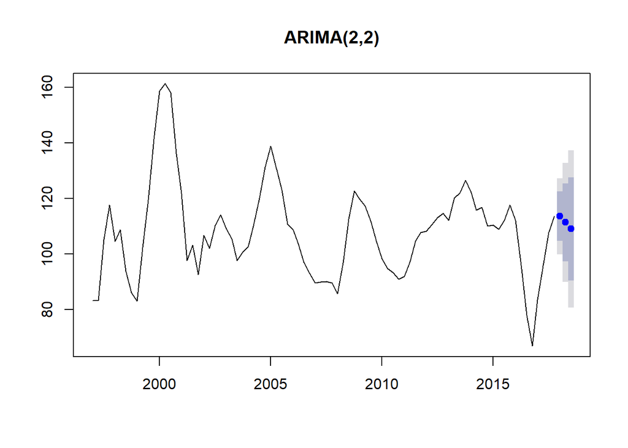

```r
plot(forecast(fit.ar2ma2, h=3), main="ARIMA(2,2)")
```

> 자동 모형선택

```r
auto.arima(ts.data)
```

```
## Series: ts.data
## ARIMA(2,0,2) with non-zero mean
##
## Coefficients:
##          ar1      ar2      ma1     ma2      mean
##       1.3021  -0.6073  -0.0936  0.3950  107.8901
## s.e.  0.2055   0.1759   0.2407  0.1411    3.2175
##
## sigma^2 estimated as 51.69:  log likelihood=-283.58
## AIC=579.15   AICc=580.24   BIC=593.74
```

```r
detach("package:forecast", unload=TRUE)
detach("package:tseries", unload=TRUE)
```

ARIMA(2,2) 모형선택

# 2. “Bank.txt” 데이터를 이용하여 다음과 같은 그래프를 작성할 수 있는 R프로그램을 작성하시오.

데이터 불러오기

```r
setwd("e:/mydata/")
Bank.Data<-read.table("Bank.txt", header=TRUE, sep="\t")
head(Bank.Data)
```

```
##   Gender  Age Online   OLWork Income InvAmount    RoR
## 1   여자 40대     하     주문    426       102 -0.794
## 2   남자 50대     상     주문    469       133  0.536
## 3   여자 40대     하 계좌조회    418       116 -0.126
## 4   남자 50대     하   현재가    352       141 -0.894
## 5   남자 30대     상 계좌조회    491       114  0.473
## 6   남자 40대     상   현재가    487       129 -0.711
```

## (1) ggplot을 사용하여 투자금액(InvAmount)의 히스토그램과 밀도곡선을 작성하시오.[단, 막대의 구간폭은 10으로 하고, x-축 이름 등은 아래 그림과 동일하게 출력]

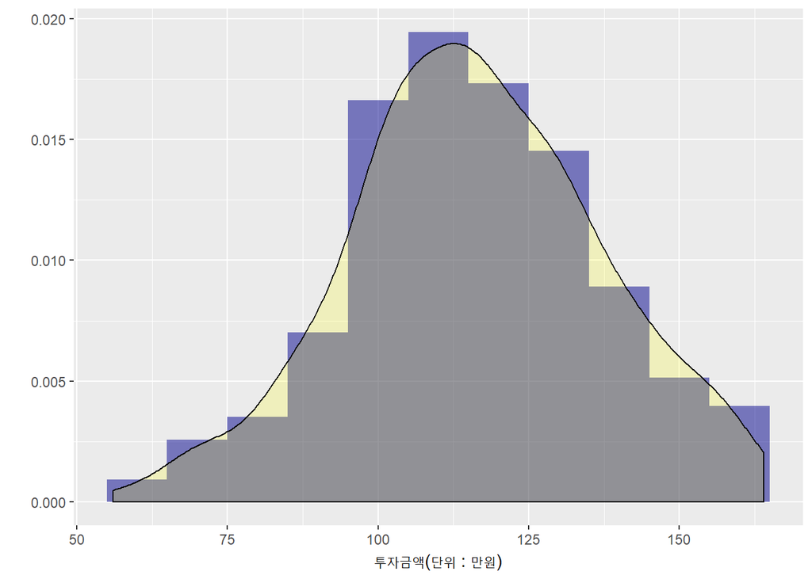

```r
library(ggplot2)
barp<-ggplot(data=Bank.Data, aes(x=InvAmount, y=..density..))
barp+geom_histogram(alpha=0.5, binwidth=10, fill="darkblue")+geom_density(alpha=0.2, fill="yellow")+xlab("투자금액(단위 : 만원)") + ylab("")
```

# (2) ggplot을 사용하여 수입(Income)과 투자금액(InvAmount) 산점도를 연령대(Age)별로 작성하시오.[단, x-축, y-축 이름은 아래 그림과 같이 출력]

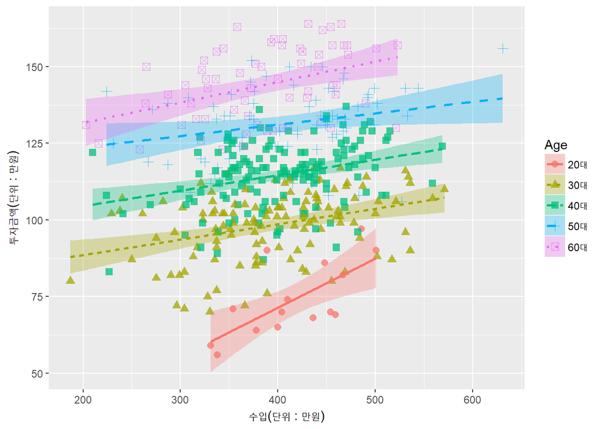

```r
barp<-ggplot(data=Bank.Data, aes(x=Income, y=InvAmount)) # 데이터와 변수 할당
barp+geom_point(aes(colour=Age, shape=Age), alpha=0.75, size=2.5)+geom_smooth(aes(colour=Age, linetype=Age, fill=Age), method=lm, alpha=0.3)+xlab("수입(단위 : 만원)") + ylab("투자금액(단위 : 만원)") # 형태(선형회귀직선 옵션 지정)
```

## (3) 성별(Gender)로 온라인거래비중(Online)에 따른 투자금액(InvAmount) 상자도표를 작성하시오.[단, x-축, y-축 이름 등은 아래 그림과 동일하게 출력]

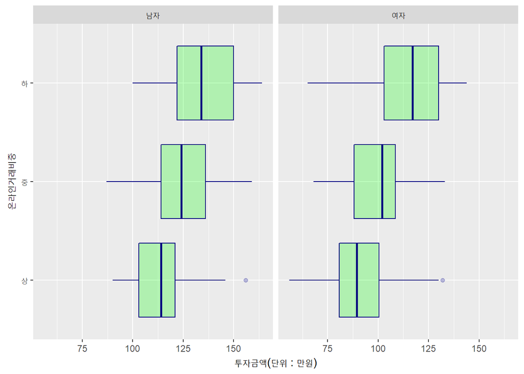

```r
barp<-ggplot(data=Bank.Data, aes(x=Online, y=InvAmount)) # 데이터와 변수 할당
barp+geom_boxplot(alpha=0.25, colour="navy", fill="green", linetype=1, outlier.shape=20, outlier.size=2.5, outlier.color="darkblue")+coord_flip()+facet_grid(~Gender)+xlab("온라인거래비중") + ylab("투자금액(단위 : 만원)")  # 수평, 수직분할
```

```r
detach("package:ggplot2", unload=TRUE)
```

# 3. 자신의 집과 단국대학교를 지도상에 표시하고 직선으로 연결하시오.

단국대학교 주소 : 경기도 용인시 수지구 죽전로 152

```r
library(ggmap)
```

```r
library(ggplot2)

# 주소 입력
add<-c("서울시 마포구", "경기도 용인시 수지구 죽전로 152")

# 지점 위도와 경도
gc<-geocode(enc2utf8(add)) #주소를 경도,위도로 변환
k<-length(gc)
i<-1
repeat {
  if(any(is.na(gc[i, ]))) {
    tmp<-geocode(enc2utf8(add[i])) #주소를 경도,위도로 변환
    gc[i, ]<-tmp
  }

  if(any(is.na(gc[i, ]))) next
  else i<-i+1

  if(i>k) break
}
gc
```

```
##        lon      lat
## 1 126.9084 37.56376
## 2 127.1279 37.32295
```

[figure not shown]

```r
# 지도에 마커 및 지점명 표시
cen<-c(mean(gc$lon), mean(gc$lat)) # 지도 중심위치
map<-get_googlemap(center=cen, maptype="roadmap", zoom=11, marker=gc)  # 지도+마커 화면에 보이기
gmap <- ggmap(map)
gmap+geom_line(data=gc, aes(x=lon,y=lat), size=2)+
  geom_text(data=gc, aes(x=lon,y=lat), hjust=1, size=4, label=c("우리집", "단국대학교\n죽전캠퍼스"))
```

```r
detach("package:ggmap", unload=TRUE)
detach("package:ggplot2", unload=TRUE)
```